# DotPlot Color Scales and Count Normalization

Newton Martin

2023-04-14

## Introduction

- How does log-normalization affect the descriptive statistics of the data (spread, normality, etc.)?
- Could I calculate the average expression with the log-normalized raw values? If so, would it still need to be transformed again to be put on a color scale?
- How do using the l-n raw values affect the interpretation of average expression?
- Do zeros have a stronger or weaker influence on the average?
- Is median expression of any value?
- Since each gene is its own assay would it be valuable to have each gene in its own Cartesian and on its own color scale?

These questions will be explored 1 by 1 in this document.

## How does log-normalization affect the descriptive statistics of the data (spread, normality, etc.)?

log1p(3) + log1p(2) is equivalent to log(4) + log(3) or log((3 + 1) * (2 + 1)). Exponentiating the result then becomes either further tricky because you cannot just run expm1. And when you just exp you wonder how that value got from 5 counts in group A to 12 total loged counts per group. The 12 has less meaning than the 5. Therefore, its better to unlog it.

### How does this affect the averages, their interpretaion and their values? Are the values still in the correct order?

Does log-normalization make the counts more normally distributed? To test for normality of the logged and unlogged counts plot them on a histogram to see the shape of the distribution and then perform a Kolmogorov-Smirnov test for normality since the sample size in this case is the number of cells. [biological replicates] It would take more work but it would be interesting to see the spread of each gene per sample. Even the non zero values follow a trend of positive skew.

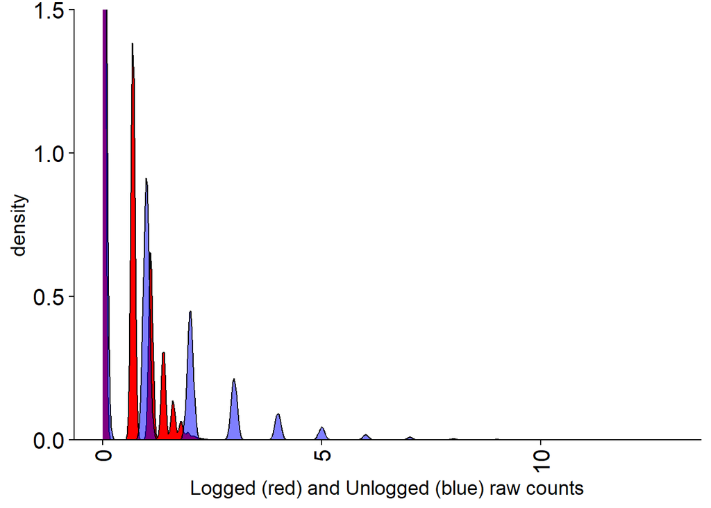

```r
all_cell_roster %>%
  ggplot() +
  geom_density(aes(x = raw_counts),
                 fill = "red", binwidth = 0.05) +
  geom_density(aes(x = expm1(raw_counts)),
                 fill = "blue", alpha = 0.5, binwidth = 0.1) +
  labs(x = "Logged (red) and Unlogged (blue) raw counts") +
  scale_y_continuous(expand = c(0, 0)) +
  coord_cartesian(ylim = c(0, 1.5)) +
  #scale_y_break(c(20000, 74000)) +
  themegsc
```

```r
ks.test(all_cell_roster$raw_counts, "pnorm")
```

```
##
##  Asymptotic one-sample Kolmogorov-Smirnov test
##
## data:  all_cell_roster$raw_counts
## D = 0.5, p-value < 2.2e-16
## alternative hypothesis: two-sided
```

```r
ks.test(expm1(all_cell_roster$raw_counts), "pnorm")
```

```
##
##  Asymptotic one-sample Kolmogorov-Smirnov test
##
## data:  expm1(all_cell_roster$raw_counts)
## D = 0.5, p-value < 2.2e-16
## alternative hypothesis: two-sided
```

[What does this mean?] The log normalization just restricts the range. It does not make the data more normal in this case.

Plotting the distribution of counts for each gene with a vertical representaion of the mean.

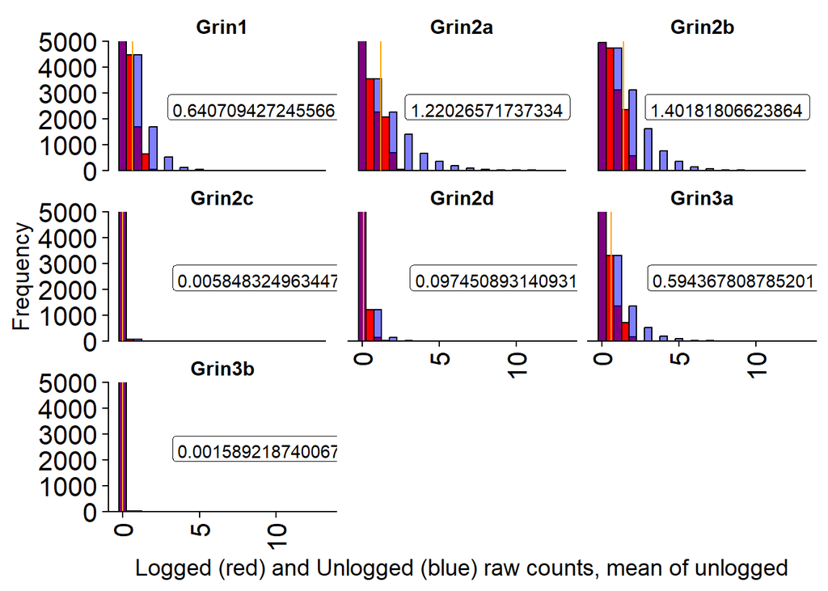

```r
all_cell_roster %>%
  #filter(cluster == "Inhib-9") %>%
  ggplot() +
  geom_histogram(aes(x = raw_counts), color = "black",
                 fill = "red", binwidth = 0.5) +
  geom_histogram(aes(x = expm1(raw_counts)), color = "black",
                 fill = "blue", alpha = 0.5, binwidth = 0.5) +
  stat_summary(aes(x = 0.1, y = expm1(raw_counts), xintercept = stat(y), group = features.label),
               fun = mean, geom = "vline", color = "orange") +
  stat_summary(aes(x = 0.1, y = expm1(raw_counts), label = stat(y), group = features.label),
               fun = mean, geom = "label", vjust = -2, hjust = -0.25) +
  labs(x = "Logged (red) and Unlogged (blue) raw counts, mean of unlogged",
       y = "Frequency") +
  scale_y_continuous(expand = c(0, 0)) +
  coord_cartesian(ylim = c(0, 5000)) +
  facet_wrap(~features.label) +
  themegsc
```

Figure: Histogram of the raw counts for each GRIN gene separately. In red there are the log(x + 1) raw counts as they are normally in Seurat object. In the blue are the raw counts without the log transformation. The orange line is the average expression of each gene across all of the cells.

However if the data is not normal should we be using the average to represent it or is there more information to be gained from the spread of the data.

What does the CPM or CPT scale do to the data. Here we calculate counts per million and counts per total. Counts per total was a mistaken calculation that ended up showing the same patterns on the dotplot. Counts per total values are so small that we cannot put them and CPM values on the same graph.

```r
all_cell_roster$CPM <- run_CPM(all_cell_roster, "CPM")$raw_counts
all_cell_roster$CPM2 <- run_CPM(all_cell_roster, "CPM", pre.exp = T)$raw_counts
all_cell_roster
```

```
## # A tibble: 110,117 × 12
##    featu…¹ cell.…² raw_c…³ cluster dataset age   run   nCoun…⁴ id    subgr   CPM
##    <chr>   <chr>     <dbl> <fct>   <chr>   <fct> <chr>   <dbl> <lis> <lis> <dbl>
##  1 Grin1   SRR604…   1.10  Inhib-… Sathya… Sath… SRR6…   12470 <chr> <chr>  88.1
##  2 Grin1   SRR604…   1.10  Excit-… Sathya… Sath… SRR6…    1452 <chr> <chr> 757.
##  3 Grin1   SRR604…   0     Excit-… Sathya… Sath… SRR6…     971 <chr> <chr>   0
##  4 Grin1   SRR604…   1.10  Inhib-1 Sathya… Sath… SRR6…    8375 <chr> <chr> 131.
##  5 Grin1   SRR604…   0.693 Inhib-2 Sathya… Sath… SRR6…    1170 <chr> <chr> 592.
##  6 Grin1   SRR604…   0.693 Excit-… Sathya… Sath… SRR6…    4003 <chr> <chr> 173.
##  7 Grin1   SRR604…   0     Excit-4 Sathya… Sath… SRR6…    1244 <chr> <chr>   0
##  8 Grin1   SRR604…   0     Inhib-5 Sathya… Sath… SRR6…    1347 <chr> <chr>   0
##  9 Grin1   SRR604…   0.693 Excit-… Sathya… Sath… SRR6…    8973 <chr> <chr>  77.2
## 10 Grin1   SRR604…   0     Inhib-2 Sathya… Sath… SRR6…    4847 <chr> <chr>   0
## # … with 110,107 more rows, 1 more variable: CPM2 <dbl>, and abbreviated
## #   variable names ¹features.label, ²cell.barcode, ³raw_counts, ⁴nCount_RNA
```

```r
ks.test(all_cell_roster$CPM, "pnorm")
```

```
##
##  Asymptotic one-sample Kolmogorov-Smirnov test
##
## data:  all_cell_roster$CPM
## D = 0.5, p-value < 2.2e-16
## alternative hypothesis: two-sided
```

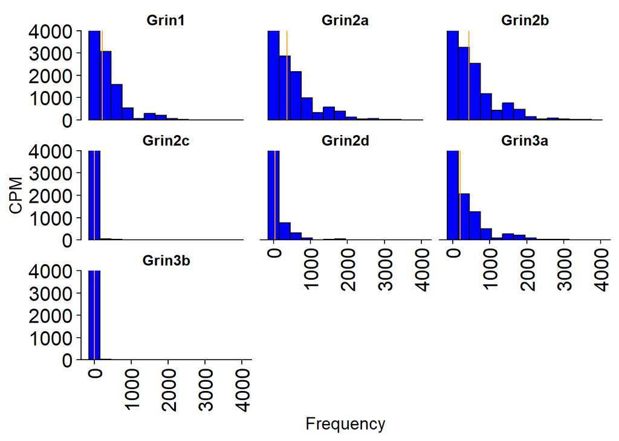

```r
# CPM
all_cell_roster %>%
  ggplot() +
  geom_histogram(aes(x = CPM), fill = "blue", binwidth = 300, color = "black") +
  stat_summary(aes(x = 0.1, y = CPM, xintercept = stat(y), group = features.label),
               fun = mean, geom = "vline", color = "orange") +
  labs(x = "Frequency") +
  scale_y_continuous(expand = c(0, 0)) +
  coord_cartesian(ylim = c(0, 4000)) +
  facet_wrap(~features.label) +
  themegsc
```

Figure: Histogram of the counts per million (CPM) for each GRIN gene separately. The CPM was calculated by getting the ratio between the log(x + 1) raw count and the total number of counts for that cell then multiplying the ratio by 1 million. The orange line is the average expression of each gene across all of the cells.

### Alternatives to the dot plot

#### The boxplot with color for pct express

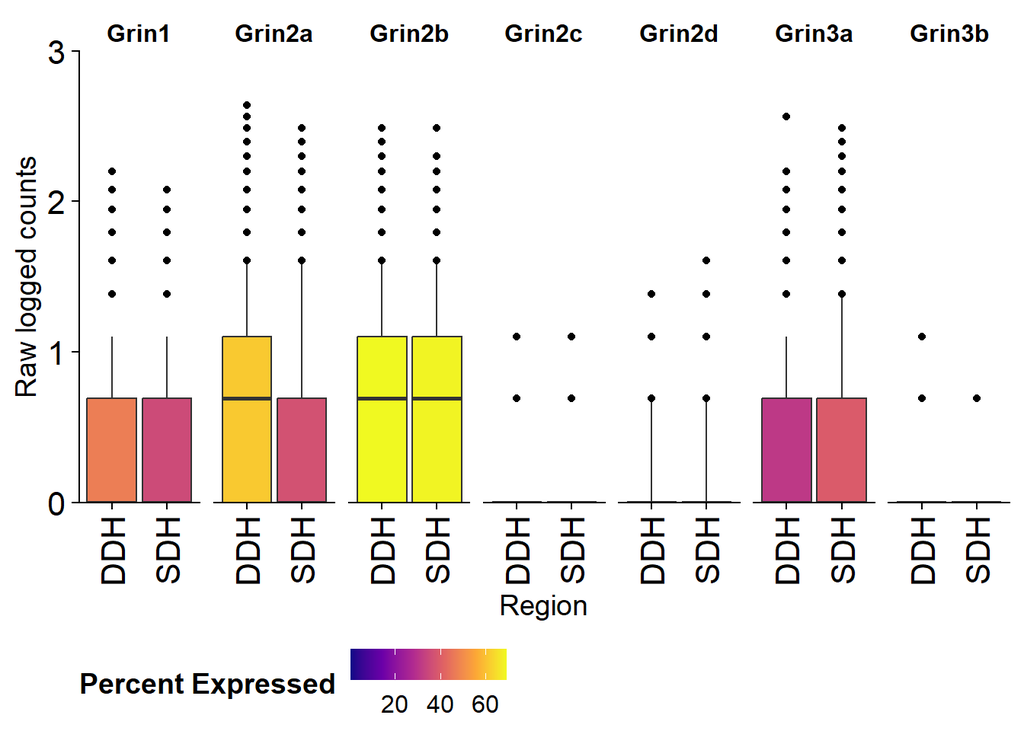

```r
ung_acr <- group_expand(all_cell_roster, overgrouped = "id")

# Get the points that are outliers above 90 or below 10% quartile.
bp_points <- function(x) {
  subset(x, x < quantile(x, probs = 0.1) | quantile(x, probs = 0.9) < x)
}

ung_acr %>%
  ggplot(aes(id, raw_counts)) +
  stat_summary(
    aes(
      fill = after_stat(pct.exp)
    ),
    geom="boxplot",
    fun.data = ~ data.frame(ymin = quantile(.x, 0.05),
                            lower = quantile(.x, 0.25),
                            middle = quantile(.x, 0.5),
                            upper = quantile(.x, 0.75),
                            ymax = quantile(.x, 0.95),
                            pct.exp = pct_calc(.x))) +
  stat_summary(fun.y = bp_points, geom="point") +
  labs(x = "Region", y = "Raw logged counts", fill = "Percent Expressed") +
  facet_grid(~features.label) +
  scale_y_continuous(expand = c(0, 0)) +
  coord_cartesian(ylim = c(0, p5max(all_cell_roster$raw_counts))) +
  scale_fill_viridis_c(option = "plasma") +
  themegsc
```

Figure: Box plot showing the median and interquartile range (IQR) of raw log(x + 1) counts. The IQR contains those higher than 25% but lower than 75%. The color of the box plot is for the percent expressed on a color scale.

We are unable to see the percent expressed of the groups with a lot of zeroes. The percent expressed gives information on whether or not we can accept the value or not [change wording here]. We can add the color scale perhaps in another way with a line at the top.

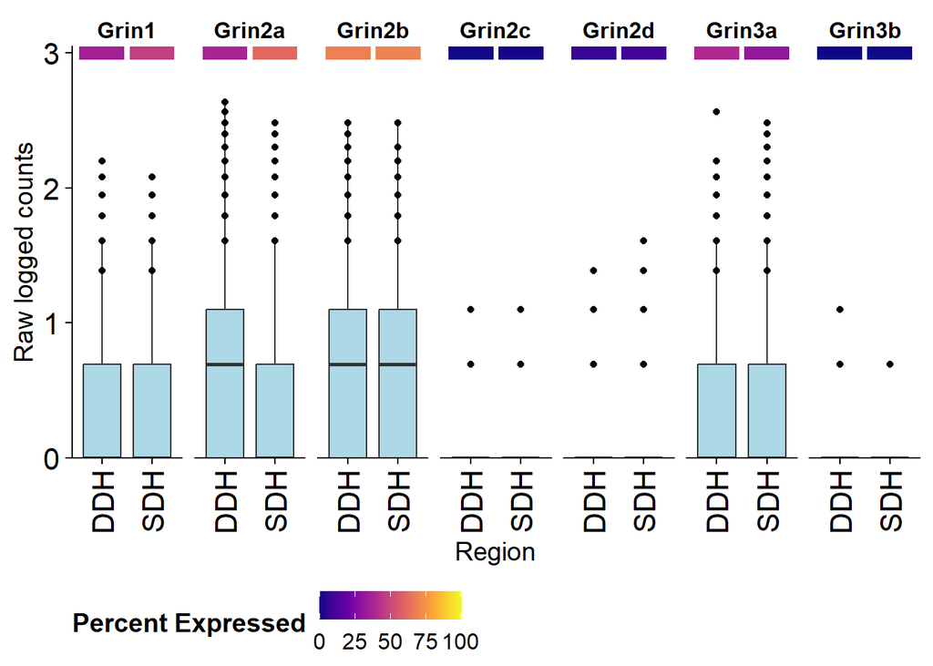

```r
# Function for plotting the pct.exp a bars on the top.
index <- 1
pct_rect <- function (x, width, height, location) {
  # This for the grid faceting
  if (index == 2) {
    index <<- 1
  } else if (index == 1) {
    index <<- 2
  }
  dims <- data.frame(pct.exp = pct_calc(x),
                     ymin = location - (height / 2),
                     ymax = location + (height / 2)) %>%
    mutate(seqnum = index,
           xmin = seqnum - (width / 2),
           xmax = seqnum + (width / 2))
  dims
}

loc <- p5max(all_cell_roster$raw_counts)

# Draw the plot
ung_acr %>%
  ggplot(aes(id, raw_counts)) +
  geom_boxplot(aes(y = raw_counts, x  = id), fill = "lightblue") +
  stat_summary(
    aes(fill = after_stat(pct.exp)),
    geom="rect",
    fun.data = ~ pct_rect(.x,
                          width = 0.9,
                          height = 0.1,
                          location = loc)) +
  stat_summary(fun.y = bp_points, geom="point") +
  labs(x = "Region", y = "Raw logged counts", fill = "Percent Expressed") +
  facet_grid(~features.label) +
  scale_y_continuous(expand = c(0, 0)) +
  scale_fill_viridis_c(option = "plasma", limits = c(0, 100)) +
  themegsc
```

Figure: Box plot showing the median and interquartile range (IQR) of raw log(x + 1) counts. The IQR contains those higher than 25% but lower than 75%. The color block above each box plot is for the percent expressed on a color scale.

We can also try it with violin plots.

Modify the dotplot to show the median count rather than the average.

```r
lbc <- createListbyCluster(scale.method = "noscale")
```

[figure not shown]

```r
lbc %>%
    ggplot() +
    geom_point(aes(y = features.label, x = cluster, color = med.exp, size = pct.exp)) +
    geom_label(aes(y = features.label, x = cluster, label = signif(med.exp, digits = 2))) +
    geom_label(aes(y = features.label, x = cluster, label = signif(avg.exp, digits = 2)),
               vjust = 2, fill = "lightblue") +
    labs(x = "Cluster", y = "Gene", color = "Med exp", size = "% Expressing") +
    scale_size(range = c(0, 20)) +
    scale_color_viridis_c(option = "plasma") +
    cowplot::theme_cowplot() +
    theme(axis.text.x = element_text(angle = 90, vjust = 0.5,# 90 0.5
                                     hjust = 1, size = global_size,
                                     color = "black"),
          axis.text.y = element_text(angle = 0, vjust = 0.5,
                                     hjust = 1, size = global_size,
                                     color = "black"),
          axis.title = element_text(size = global_size, face = "bold"),
          legend.key.size = unit(1.5, "line"),
          legend.text = element_text(size = global_size/1.75),
          legend.title = element_text(size = global_size, angle = 90),
          legend.spacing.x = unit(1.5, "line"),
          plot.background = element_rect(fill = "white"))
```

Figure: Median expression and percent expressed of GRIN genes of spinal cord dorsal horn neuronal subpopulations from Russ et al. (2021). The median expression is represented as the color of the dot. The percent expressed is represented by the size of each dot. The white label is the value of the median expression and the blue label is the value of average expression.

It shows the maximum counts for a gene expressed in the lowest 50 of cells of a group. [Needs obvious re-wording]. Interesting how 0, 0.69 and 1.1 are very common is that relevant. It could be that the massive amount of zeros causes any group with a percent expressed around 50 to have a particular value. It is also peculiar why every group has a cell with a count of 0.6931.

Table: Median expression and percent expressed of GRIN genes of spinal cord dorsal horn neuronal subpopulations from Russ et al. (2021). Median expression metric has very particular values

```r
lbc %>%
  filter(pct.exp >= 50) %>%
  arrange(pct.exp)
```

```
## # A tibble: 101 × 6
##    cluster  features.label avg.exp pct.exp med.exp avg.exp.scaled
##    <fct>    <chr>            <dbl>   <dbl>   <dbl>          <dbl>
##  1 Excit-3  Grin2b           0.913    50.2   0.693          0.913
##  2 Excit-4  Grin3a           1.07     50.3   0.693          1.07
##  3 Excit-32 Grin1            0.611    50.3   0.693          0.611
##  4 Inhib-15 Grin2a           0.916    51.2   0.693          0.916
##  5 Inhib-6  Grin2b           0.862    51.6   0.693          0.862
##  6 Excit-14 Grin3a           0.893    51.8   0.693          0.893
##  7 Inhib-19 Grin1            0.676    51.8   0.693          0.676
##  8 Inhib-1  Grin1            0.871    52.1   0.693          0.871
##  9 Excit-6  Grin2b           1.01     52.6   0.693          1.01
## 10 Excit-13 Grin3a           0.874    52.9   0.693          0.874
## # … with 91 more rows
```

```r
unique(lbc$med.exp)
```

```
## [1] 0.0000000 1.0986123 0.6931472 1.3862944 0.8958797
```

Seeing the same number pop up so many times cannot be coincidence. Lets plot the data as a box plot to find out more.

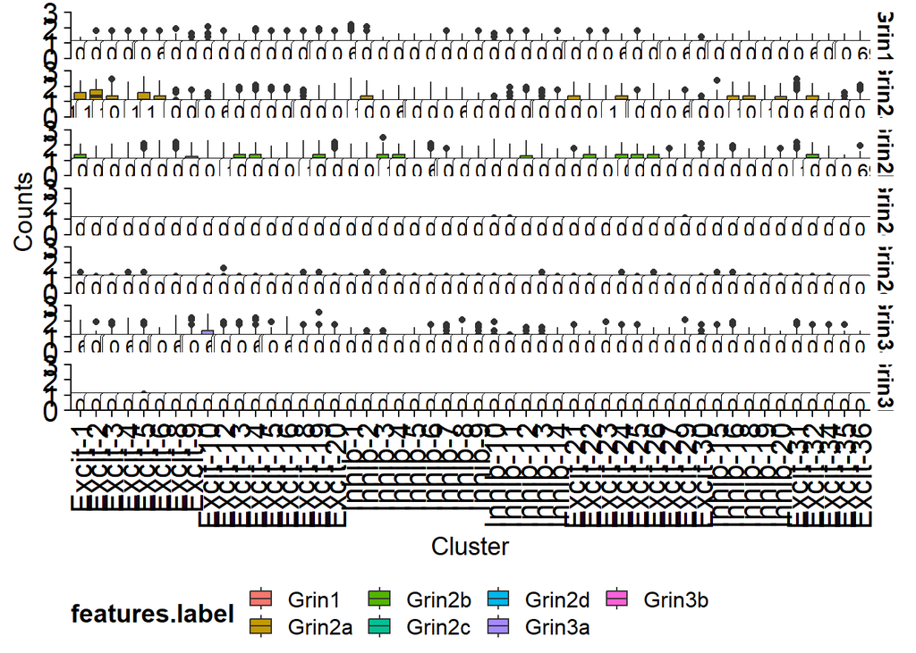

```r
all_cell_roster %>%
  ggplot(aes(cluster, raw_counts)) +
  geom_boxplot(aes(fill = features.label)) +
  stat_summary(aes(x = cluster, y = stage(raw_counts, after_stat = 3),
                   label = after_stat(signif(middle, 2))),
               vjust = 2, fun.data = ~ data.frame(middle = quantile(.x, 0.5)), geom = "label") +
  facet_grid(rows = vars(features.label)) +
  labs(x = "Cluster", y = "Counts") +
  scale_y_continuous(expand = c(0, 0)) +
  themegsc
```

Figure: Box plot for each GRIN gene and neuronal cluster in spinal cord dorsal horn from the Russ et al. (2021) mouse data. The label above each group is the median value.

It does not tell us much because some of them have different spred but the same median. Still others have similar spread and wildly different medians. Perhsaps looking at the distribution would be more helpful with the use of violin plots.

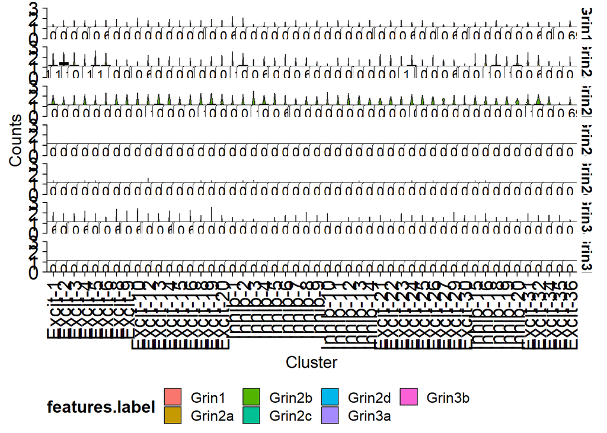

```r
all_cell_roster %>%
  ggplot(aes(cluster, raw_counts)) +
  geom_violin(aes(fill = features.label)) +
  stat_summary(fun = median, geom = "crossbar", position = position_dodge(width = 0.8)) +
  stat_summary(aes(x = cluster, y = stage(raw_counts, after_stat = 3),
                   label = after_stat(signif(middle, 2))),
               vjust = 2, fun.data = ~ data.frame(middle = quantile(.x, 0.5)), geom = "label") +
  facet_grid(rows = vars(features.label)) +
  labs(x = "Cluster", y = "Counts") +
  scale_y_continuous(expand = c(0, 0)) +
  themegsc
```

Figure: Violin plot for each GRIN gene and neuronal cluster in spinal cord dorsal horn from the Russ et al. (2021) mouse data. The label above each group is the median value.

We could also see if the median changes when we use the CPM scale.

[figure not shown]

```r
all_cell_roster %>%
  group_by(features.label, cluster) %>%
  run_CPM("CPM") %>%
  summarise(med.exp = median(raw_counts),
            pct.exp = pct_calc(raw_counts),
            avg.exp = mean(raw_counts)) %>%
  ungroup(features.label, cluster) %>%
  ggplot() +
    geom_point(aes(y = features.label, x = cluster, color = med.exp, size = pct.exp)) +
    geom_label(aes(y = features.label, x = cluster, label = signif(med.exp, digits = 2))) +
    geom_label(aes(y = features.label, x = cluster, label = signif(avg.exp, digits = 2)),
               vjust = 2, fill = "lightblue") +
    labs(x = "Cluster", y = "Gene", color = "Med exp", size = "% Expressing") +
    scale_size(range = c(0, 20)) +
    scale_color_viridis_c(option = "plasma") +
    cowplot::theme_cowplot() +
    theme(axis.text.x = element_text(angle = 90, vjust = 0.5,# 90 0.5
                                     hjust = 1, size = global_size,
                                     color = "black"),
          axis.text.y = element_text(angle = 0, vjust = 0.5,
                                     hjust = 1, size = global_size,
                                     color = "black"),
          axis.title = element_text(size = global_size, face = "bold"),
          legend.key.size = unit(1.5, "line"),
          legend.text = element_text(size = global_size/1.75),
          legend.title = element_text(size = global_size, angle = 90),
          legend.spacing.x = unit(1.5, "line"),
          plot.background = element_rect(fill = "white"))
```

Figure: Median CPM expression and percent expressed of GRIN genes of spinal cord dorsal horn neuronal cluster from the Russ et al. (2021) mouse. The median expression is represented as the color of the dot. The percent expressed is represented by the size of each dot. The white label is the value of the median CPM expression and the blue label is the value of average CPM expression.

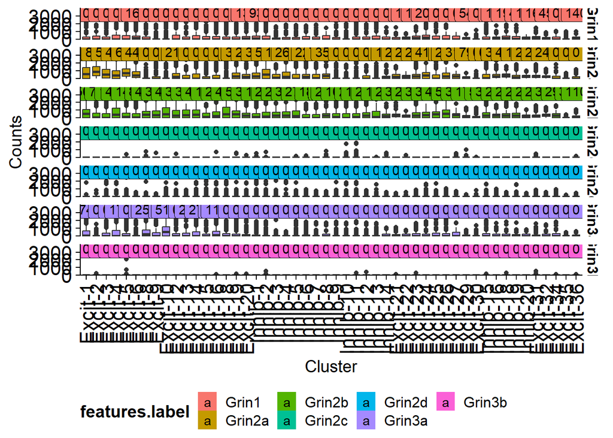

```r
all_cell_roster %>%
  run_CPM("CPM") %>%
  ggplot(aes(cluster, raw_counts)) +
  geom_boxplot(aes(fill = features.label)) +
  stat_summary(aes(x = cluster, y = stage(raw_counts, after_stat = 3500),
                   label = after_stat(signif(middle, 2)), fill = features.label),
               fun.data = ~ data.frame(middle = quantile(.x, 0.5)), geom = "label") +
  facet_grid(rows = vars(features.label)) +
  labs(x = "Cluster", y = "Counts") +
  scale_y_continuous(expand = c(0, 0)) +
  themegsc
```

Figure: Box plot for each GRIN gene and neuronal cluster in spinal cord dorsal horn from the Russ et al. (2021) mouse data. The data was first transformed to the CPM value. The label above each group is the median CPM value.

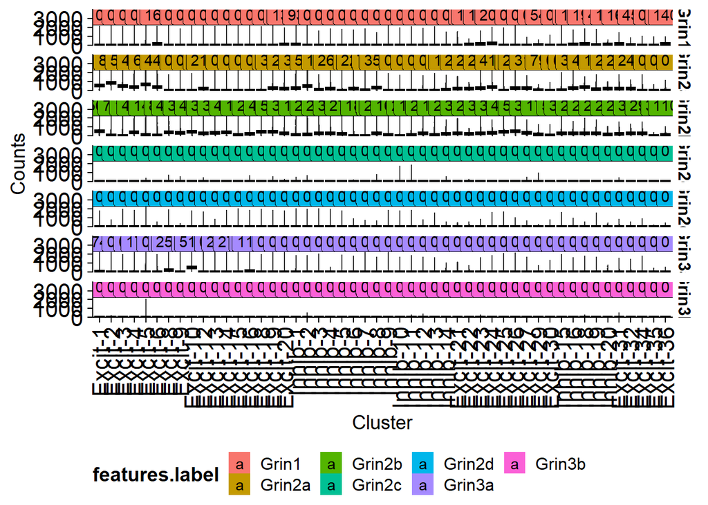

```r
all_cell_roster %>%
  run_CPM("CPM") %>%
  ggplot(aes(cluster, raw_counts)) +
  geom_violin(aes(fill = features.label)) +
  stat_summary(fun = median, geom = "crossbar", position = position_dodge(width = 0.8)) +
  stat_summary(aes(x = cluster, y = stage(raw_counts, after_stat = 3500),
                   label = after_stat(signif(middle, 2)), fill = features.label),
               fun.data = ~ data.frame(middle = quantile(.x, 0.5)), geom = "label") +
  facet_grid(rows = vars(features.label)) +
  labs(x = "Cluster", y = "Counts") +
  scale_y_continuous(expand = c(0, 0)) +
  themegsc
```

Figure: Violin plot for each GRIN gene and neuronal cluster in spinal cord dorsal horn from the Russ et al. (2021) mouse data. The data was first transformed to the CPM value. The label above each group is the median CPM value.

It is pointless to look for one metric that represents all of the data. Average does not seem like it would work here but niether does median. Each of them is equally hard to conceptualize as to the biological relevance. Although some patterns do jump out. For instance, the groups with similar medians tend to have similar shapes but that rule is not always true. At least with the average each group has a different value depending on all the data points not just the lower 50%.

What we can try doing is putting each gene on its own scale using average expression. First without CPM.

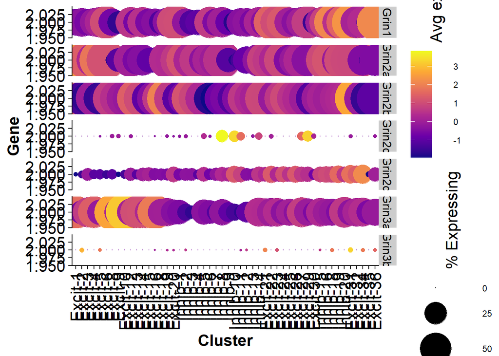

```r
all_cell_roster %>%
  #run_CPM("CPM") %>%
  group_by(features.label, cluster) %>%
  summarise(avg.exp = mean(raw_counts),
            pct.exp = pct_calc(raw_counts)) %>%
  ungroup(cluster) %>%
  mutate(avg.exp.scaled = zs_calc(avg.exp)) %>%
  ungroup(features.label) %>%
  ggplot() +
  geom_point(aes(y = 2, x = cluster, color = avg.exp.scaled, size = pct.exp)) +
  labs(x = "Cluster", y = "Gene", color = "Avg exp z scaled per gene", size = "% Expressing") +
  scale_size(range = c(0, 20)) +
  scale_color_viridis_c(option = "plasma") +
  facet_grid(rows = vars(features.label), scales = "free") +
  cowplot::theme_cowplot() +
  theme(axis.text.x = element_text(angle = 90, vjust = 0.5,# 90 0.5
                                    hjust = 1, size = global_size,
                                    color = "black"),
        axis.text.y = element_text(angle = 0, vjust = 0.5,
                                    hjust = 1, size = global_size,
                                    color = "black"),
        axis.title = element_text(size = global_size, face = "bold"),
        legend.key.size = unit(1.5, "line"),
        legend.text = element_text(size = global_size/1.75),
        legend.title = element_text(size = global_size, angle = 90),
        legend.spacing.x = unit(1.5, "line"),
        plot.background = element_rect(fill = "white"))
```

Figure: Average expression and percent expressed of GRIN genes of spinal cord dorsal horn neuronal cluster from the Russ et al. (2021) mouse. The average expression is represented as the color of the dot and the color scale is a z score. The z-score was calculated separately for each gene. The percent expressed is represented by the size of each dot.

With CPM

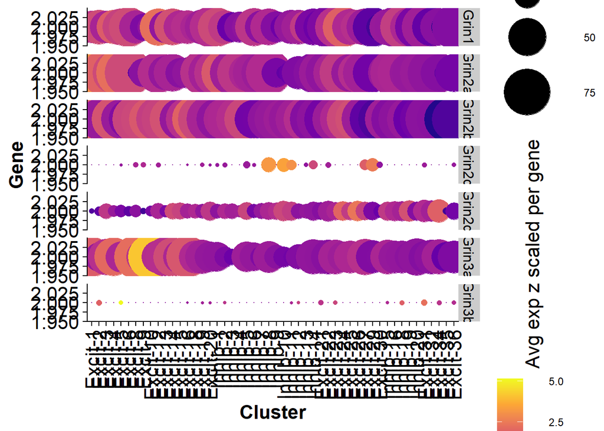

```r
all_cell_roster %>%
  run_CPM("CPM") %>%
  group_by(features.label, cluster) %>%
  summarise(avg.exp = mean(raw_counts),
            pct.exp = pct_calc(raw_counts)) %>%
  ungroup(cluster) %>%
  mutate(avg.exp.scaled = zs_calc(avg.exp)) %>%
  ungroup(features.label) %>%
  ggplot() +
  geom_point(aes(y = 2, x = cluster, color = avg.exp.scaled, size = pct.exp)) +
  labs(x = "Cluster", y = "Gene", color = "Avg exp z scaled per gene", size = "% Expressing") +
  scale_size(range = c(0, 20)) +
  scale_color_viridis_c(option = "plasma") +
  facet_grid(rows = vars(features.label), scales = "free") +
  cowplot::theme_cowplot() +
  theme(axis.text.x = element_text(angle = 90, vjust = 0.5,# 90 0.5
                                    hjust = 1, size = global_size,
                                    color = "black"),
        axis.text.y = element_text(angle = 0, vjust = 0.5,
                                    hjust = 1, size = global_size,
                                    color = "black"),
        axis.title = element_text(size = global_size, face = "bold"),
        legend.key.size = unit(1.5, "line"),
        legend.text = element_text(size = global_size/1.75),
        legend.title = element_text(size = global_size, angle = 90),
        legend.spacing.x = unit(1.5, "line"),
        plot.background = element_rect(fill = "white"))
```

Figure: Average CPM expression and percent expressed of GRIN genes of spinal cord dorsal horn neuronal cluster from the Russ et al. (2021) mouse. The average CPM expression is represented as the color of the dot and the color scale is a z score. The z-score was calculated separately for each gene. The percent expressed is represented by the size of each dot.

What do I learn from this One benefit is that a cluster with enormously large average expression in one gene does not result in a color scale where all of the other differences across clusters and genes is hard to see.

I have seen Dr. Levine and team use a z-score on log(CPM + 1) transformed counts.

```r
lbc <- createListbyCluster(scale.method = "zsoflog1pCPM", pre.expm1 = T)
lbc <- createListbyCluster(scale.method = "zsoflog1pCPM", pre.expm1 = F)
```

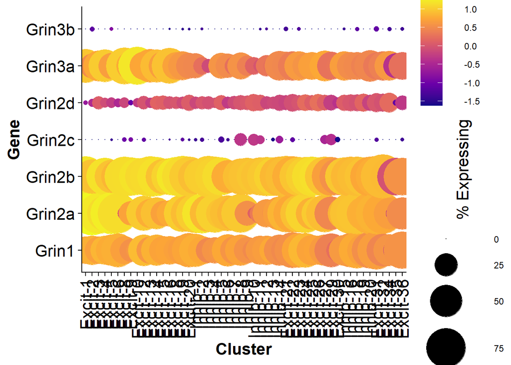

```r
lbc %>%
    ggplot() +
    geom_point(aes(y = features.label, x = cluster, color = avg.exp.scaled, size = pct.exp)) +
    labs(x = "Cluster", y = "Gene",
         color = wrapper("Z score on log10(CPM + 1)", width = 8),
         size = "% Expressing") +
    scale_size(range = c(0, 20)) +
    scale_color_viridis_c(option = "plasma") +
    cowplot::theme_cowplot() +
    theme(axis.text.x = element_text(angle = 90, vjust = 0.5,# 90 0.5
                                     hjust = 1, size = global_size,
                                     color = "black"),
          axis.text.y = element_text(angle = 0, vjust = 0.5,
                                     hjust = 1, size = global_size,
                                     color = "black"),
          axis.title = element_text(size = global_size, face = "bold"),
          legend.key.size = unit(1.5, "line"),
          legend.text = element_text(size = global_size/1.75),
          legend.title = element_text(size = global_size, angle = 90),
          legend.spacing.x = unit(1.5, "line"),
          plot.background = element_rect(fill = "white"))
```

Average expression and percent expressed of GRIN gene in spinal cord dorsal horn neuronal subpoplations clusters from the Russ et al. (2021) mouse data. The average expression is represented as the color of the dot and is a z-score scale of log10(CPM + 1) counts. The percent expressed is represented by the size of each dot.

There is the issue that if readers are use to seeing average expression on the color scale, then they will be intuitively look at the color scale and think that it refers to average expression, unless it was outwardly obvious. Therefore, if I were to do a DotPlot I would use average expression out of convention and to capture the shape / spread but other graphs can show so much more information and help us understand the single cell data a lot more. The next thing to consider is the biological relevance of the CPM scale, the CPT scale or average expression. Counts represent the number of detected cDNA fragments that align to a particular mRNA (based on a library). It is then normalized using TPM or other things. Then the average expression refers to the average normalized number of fragments that align to a particular gene. Counts per million is the ratio of the counts for one gene and cell to the total amount of counts for the entire cell then multiplied by 1 million. While multiplying by 1,000 or 100 would essentially yield the same ratios and therfore the same distances across assays, using 1 million is a convention that was carried over from bulk RNA seq and I find that using smaller 10s would resut in very small numbers. Counts per total is the product of the count for a particular gene and cell by the total counts of all genes in a given cell and then divided by 1 million. The resulting values are much smaller than CPM. Let us now investigate which scale is adequate for this application. Is the CPM transformation really better than just using the raw counts?